# Отчёт по прохождению 1 этапа внешнего курса

Почему не подходят другие: -xzf — x означает extract (распаковать), z — gzip, а не bzip2, -czf — z = gzip (даст .tar.gz, а не .tar.bz2), -xjf — x = extract, а не create (будет распаковывать, а не запаковывать), -wtf — w — interact, t — list contents (не create), неверная комбинация (рис. 29).

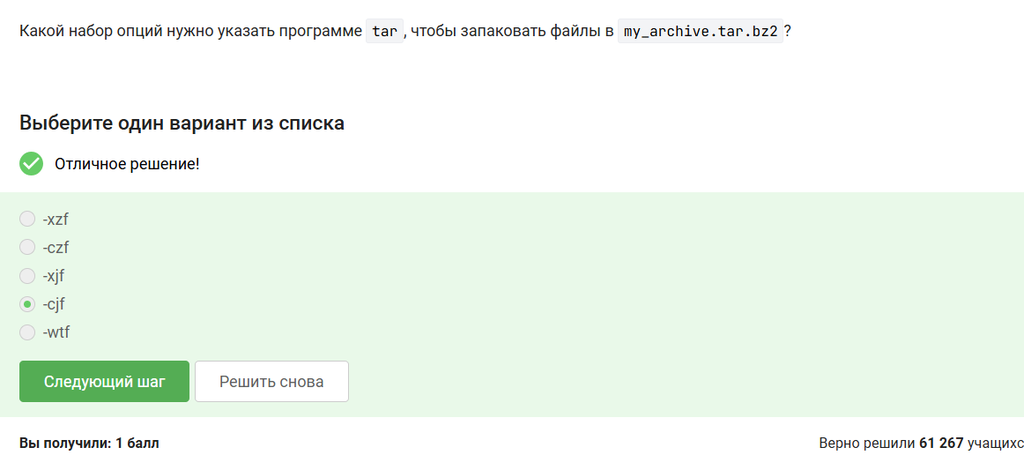

Рисунок 29: 27 задание

*.? не хватает букв, alexey.* не совпадает по регистру, *.jpg не совпадает по расширению (рис. 30).

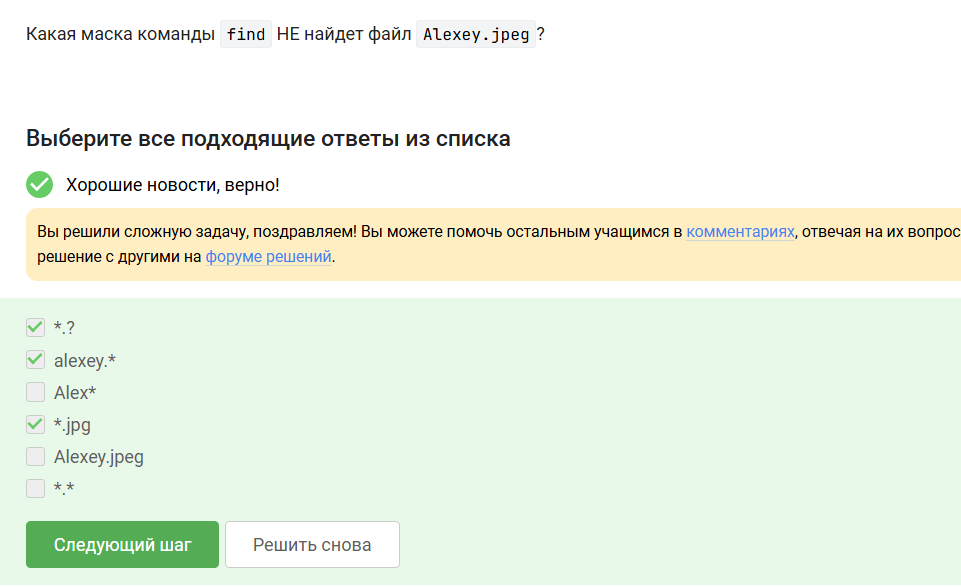

Рисунок 30: 28 задание

grep ищет точное вхождение world, с учётом регистра. Варианты с World или The World Is Not Enough не подходят (большая буква). beautiful- world и beautifulworld содержат world. The word is not enough — нет world (рис. 31).

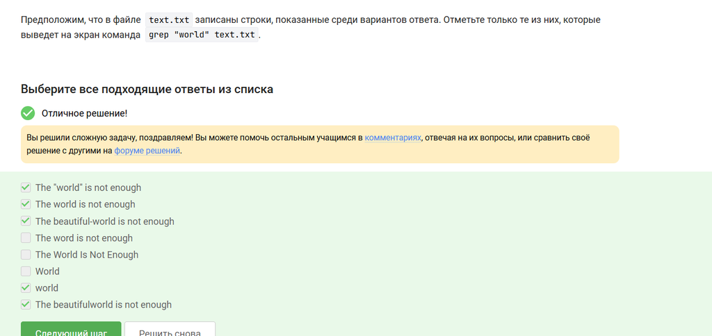

Рисунок 31: 29 задание

Я скачала архив с произведениями Шекспира, распаковала его и создала файл, в котором все строки из этих произведений, содержащие love (рис. 32).

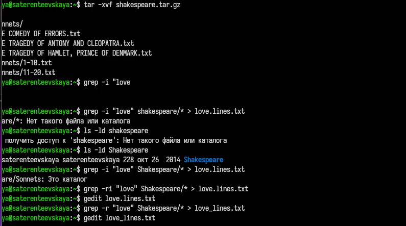

Рисунок 32: 30 задание

Загрузила в форму (рис. 33).

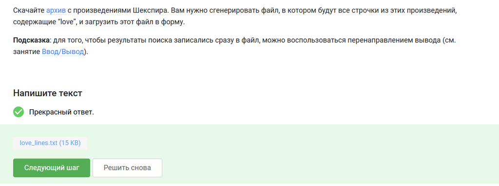

Рисунок 33: 30 задание

# Выводы

Я прошла 1 этап курса “Введение в Linux” на платформе Stepik и ознакомилась с функционалом системы Linux.

# Список литературы

[Введение в Linux](https://stepik.org/course/73/syllabus)